# Solution to 2017 M3 Challenge

```r
#install.packages("readxl")
#install.packages("ggplot2")
#install.packages("reshape2")
#install.packages("dplyr")
library(readxl)
library(ggplot2)
library(reshape2)
library(dplyr)
```

This is an outline of a method of solution of the [2017 M3 Challenge](https://m3challenge.siam.org/sites/default/files/uploads/M3%20Challenge%20PROBLEM_2017_0.pdf). The webpage with all the data is located [here](https://m3challenge.siam.org/node/336).

## Part 1 - Tides of Change

The goal is to build a mathematical model that will classify five national parks in terms of their risk of sea level change (high, medium, or low) over the next 10, 20, and 50 years.

### Step 1 - Understanding the Data

To do so, we first look at the data [NPS_MeanSeaLevel](https://m3challenge.siam.org/sites/default/files/uploads/NPS_MeanSeaLevel_1.xlsx). We look at the last sheet which contains the 20 years of mean sea level(MSL) data for the 5 national parks.

```r
library(readxl)
prob1 <- read_excel("data/NPS_MeanSeaLevel_1.xlsx", "20yr_Monthly_MSL", skip = 3)
colnames(prob1) <- c("Year", "Month", "Acadia", "Cape_Hatteras", "Kenai_Fords", "Olympic","Padre_Island")
prob1
```

| Year | Month | Acadia | Cape_Hatteras | Kenai_Fords | Olympic | Padre_Island |
| --- | --- | --- | --- | --- | --- | --- |
| 1997 | 1 | 0.056 | 0.068 | -0.017 | 0.065 | 0.059 |
| 1997 | 2 | 0.012 | 0.071 | 0.016 | -0.102 | 0.077 |
| 1997 | 3 | 0.041 | 0.064 | -0.061 | 0.015 | 0.061 |
| 1997 | 4 | 0.090 | 0.118 | -0.057 | -0.018 | 0.112 |
| 1997 | 5 | 0.042 | 0.012 | -0.108 | 0.069 | 0.002 |
| 1997 | 6 | 0.044 | 0.027 | 0.003 | 0.121 | -0.025 |
| 1997 | 7 | -0.006 | 0.023 | 0.016 | 0.050 | -0.025 |
| 1997 | 8 | 0.021 | 0.008 | -0.020 | 0.103 | -0.032 |
| 1997 | 9 | 0.046 | -0.002 | 0.060 | 0.138 | -0.054 |
| 1997 | 10 | 0.027 | 0.009 | -0.072 | 0.182 | 0.002 |

[output cut: 230 more lines]

It will first be helpful to plot the data. We first give ourselves a column that measures the number of years since January 1997.

```r
prob1$years <- as.numeric(row.names(prob1))/12
prob1
```

| Year | Month | Acadia | Cape_Hatteras | Kenai_Fords | Olympic | Padre_Island | years |
| --- | --- | --- | --- | --- | --- | --- | --- |
| 1997 | 1 | 0.056 | 0.068 | -0.017 | 0.065 | 0.059 | 0.08333333 |
| 1997 | 2 | 0.012 | 0.071 | 0.016 | -0.102 | 0.077 | 0.16666667 |
| 1997 | 3 | 0.041 | 0.064 | -0.061 | 0.015 | 0.061 | 0.25000000 |
| 1997 | 4 | 0.090 | 0.118 | -0.057 | -0.018 | 0.112 | 0.33333333 |
| 1997 | 5 | 0.042 | 0.012 | -0.108 | 0.069 | 0.002 | 0.41666667 |
| 1997 | 6 | 0.044 | 0.027 | 0.003 | 0.121 | -0.025 | 0.50000000 |
| 1997 | 7 | -0.006 | 0.023 | 0.016 | 0.050 | -0.025 | 0.58333333 |
| 1997 | 8 | 0.021 | 0.008 | -0.020 | 0.103 | -0.032 | 0.66666667 |
| 1997 | 9 | 0.046 | -0.002 | 0.060 | 0.138 | -0.054 | 0.75000000 |
| 1997 | 10 | 0.027 | 0.009 | -0.072 | 0.182 | 0.002 | 0.83333333 |

[output cut: 230 more lines]

Then we can look at a plot of Acadia

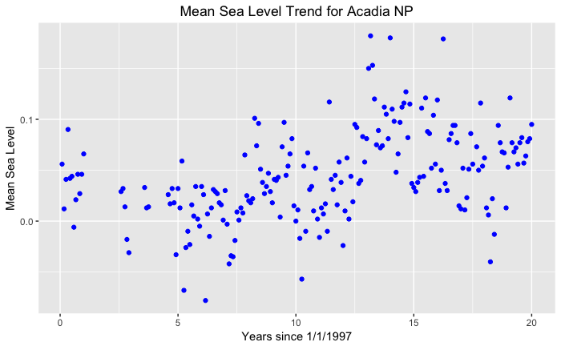

```r
ggplot(prob1, aes(years, Acadia)) +
  geom_point(na.rm = TRUE, color = "blue") +
  labs(title = "Mean Sea Level Trend for Acadia NP", x = "Years since 1/1/1997", y = "Mean Sea Level") +
  theme(plot.title = element_text(hjust = 0.5))
```

We can then add a linear fit to it.

```r
fit <- lm(Acadia ~ years, prob1)
summary(fit)
```

```
Call:
lm(formula = Acadia ~ years, data = prob1)

Residuals:
      Min        1Q    Median        3Q       Max
-0.110253 -0.024260 -0.003452  0.023021  0.130248

Coefficients:
             Estimate Std. Error t value Pr(>|t|)
(Intercept) 0.0038322  0.0066022   0.580    0.562
years       0.0036395  0.0005334   6.824 1.01e-10 ***
---
Signif. codes:  0 ‘***’ 0.001 ‘**’ 0.01 ‘*’ 0.05 ‘.’ 0.1 ‘ ’ 1

Residual standard error: 0.04042 on 202 degrees of freedom
  (36 observations deleted due to missingness)
Multiple R-squared:  0.1873,    Adjusted R-squared:  0.1833
F-statistic: 46.56 on 1 and 202 DF,  p-value: 1.012e-10
```

Notice that this linear fit has a positive slope, 3.64 mm/year, and that with such a large t-value, we can say with confidence that it is greater than 0 (i.e. there is a trend of increasing mean sea level in Acadia over the last 20 years). We can also reinforce this with a look at the 95% confidence interval for the slope in mm/year - (2.5878178, 4.6911979).

We can then add this trend line to our plot.

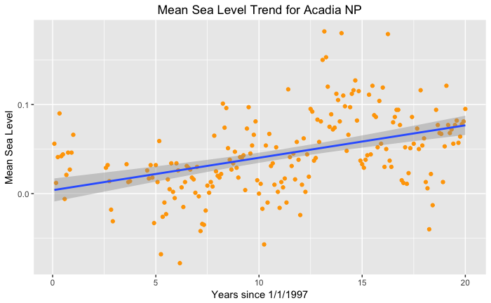

```r
ggplot(prob1, aes(years, Acadia)) +
  geom_point(na.rm = TRUE, color = "orange") +
  labs(title = "Mean Sea Level Trend for Acadia NP", x = "Years since 1/1/1997", y = "Mean Sea Level") +
  theme(plot.title = element_text(hjust = 0.5)) +
  geom_smooth(method = 'lm', formula = y ~ x, na.rm = TRUE)
```

```r
npsMSL2 <- read_excel("Data/NPS_MeanSeaLevel_1.xlsx", sheet = "MSL_trend")
npsMSL2 <- npsMSL2[1:5,-1]
npsMSL2
```

| Station location | Bar Harbor, ME | Oregon Inlet Marina, NC | Seward, AK | Port Angeles, WA | Padre Island, TX |
| --- | --- | --- | --- | --- | --- |
| Station ID | 8413320.0 | 8652587.0 | 9455090.0 | 9444090.0 | 8779750.0 |
| NPS park unit | Acadia NP | Cape Hatteras NS | Kenai Fjords NP | Olympic NP | Padre Island NS |
| Upper 95% mm/yr | 2.4 | 5.07 | -1.93 | 1.1 | 4.23 |
| MSL Trend Value mm/yr | 2.178 | 3.84 | -2.62 | 0.14 | 3.48 |
| Lower 95% mm/yr | 1.96 | 2.61 | -3.31 | -0.82 | 2.73 |

To recreate their numbers, we need to look at all the historical data from the referenced site for [Station 8413320](https://tidesandcurrents.noaa.gov/sltrends/sltrends_station.shtml?stnid=8413320).

```r
acadia <- read.csv("https://tidesandcurrents.noaa.gov/sltrends/downloadMeanSeaLevelTrendsCSV.htm?stnid=8413320")
acadia$years <- as.numeric(row.names(acadia))/12
acadia <- acadia[1:1392,] #Removing everything after the previous year
acadia
```

|  | Year | Month | Monthly_MSL | Unverified | Linear_Trend | High_Conf. | Low_Conf. | years |
| --- | --- | --- | --- | --- | --- | --- | --- | --- |
| 1 | 1900 | 1 | NA |  | -0.193 | -0.175 | -0.210 | 0.08333333 |
| 2 | 1900 | 2 | NA |  | -0.192 | -0.175 | -0.210 | 0.16666667 |
| 3 | 1900 | 3 | NA |  | -0.192 | -0.174 | -0.210 | 0.25000000 |
| 4 | 1900 | 4 | NA |  | -0.192 | -0.174 | -0.210 | 0.33333333 |
| 5 | 1900 | 5 | NA |  | -0.192 | -0.174 | -0.210 | 0.41666667 |
| 6 | 1900 | 6 | NA |  | -0.192 | -0.174 | -0.209 | 0.50000000 |
| 7 | 1900 | 7 | NA |  | -0.191 | -0.174 | -0.209 | 0.58333333 |
| 8 | 1900 | 8 | NA |  | -0.191 | -0.174 | -0.209 | 0.66666667 |
| 9 | 1900 | 9 | NA |  | -0.191 | -0.173 | -0.209 | 0.75000000 |
| 10 | 1900 | 10 | NA |  | -0.191 | -0.173 | -0.209 | 0.83333333 |

[output cut: 990 more lines]

We can plot this.

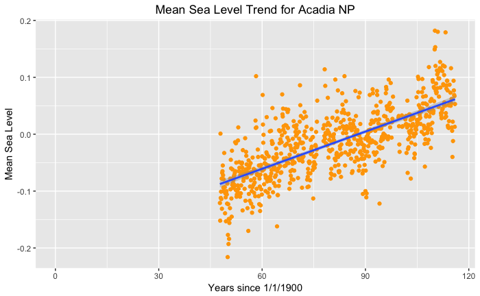

```r
ggplot(acadia, aes(years, Monthly_MSL)) +
  geom_point(na.rm = TRUE, color = "orange") +
  labs(title = "Mean Sea Level Trend for Acadia NP", x = "Years since 1/1/1900", y = "Mean Sea Level") +
  theme(plot.title = element_text(hjust = 0.5)) +
  geom_smooth(method = 'lm', formula = y ~ x, na.rm = TRUE)
```

We can look at the linear fit.

```r
fit2 <- lm(Monthly_MSL ~ years, acadia)
summary(fit2)
```

```
Call:
lm(formula = Monthly_MSL ~ years, data = acadia)

Residuals:
      Min        1Q    Median        3Q       Max
-0.135540 -0.026520 -0.002452  0.023713  0.166661

Coefficients:
              Estimate Std. Error t value Pr(>|t|)
(Intercept) -1.918e-01  6.386e-03  -30.03   <2e-16 ***
years        2.182e-03  7.636e-05   28.58   <2e-16 ***
---
Signif. codes:  0 ‘***’ 0.001 ‘**’ 0.01 ‘*’ 0.05 ‘.’ 0.1 ‘ ’ 1

Residual standard error: 0.04215 on 756 degrees of freedom
  (634 observations deleted due to missingness)
Multiple R-squared:  0.5193,    Adjusted R-squared:  0.5187
F-statistic: 816.7 on 1 and 756 DF,  p-value: < 2.2e-16
```

This gives a slope of 2.18 mm/year with a very large t-value. Again, with certainty, we can say that the sea level is rising at this location. We can look at the 95% confidence interval for the slope in mm/year - (2.032426, 2.3322401). This more closely mirrors the values they gave in the Excel sheet.

We will now look at all the stations.

```r
prob1Melt <- melt(prob1, id.vars=c("Year", "Month", "years"), variable.name = "National_Park", value.name = "MSL")
prob1Melt
```

| Year | Month | years | National_Park | MSL |
| --- | --- | --- | --- | --- |
| 1997 | 1 | 0.08333333 | Acadia | 0.056 |
| 1997 | 2 | 0.16666667 | Acadia | 0.012 |
| 1997 | 3 | 0.25000000 | Acadia | 0.041 |
| 1997 | 4 | 0.33333333 | Acadia | 0.090 |
| 1997 | 5 | 0.41666667 | Acadia | 0.042 |
| 1997 | 6 | 0.50000000 | Acadia | 0.044 |
| 1997 | 7 | 0.58333333 | Acadia | -0.006 |
| 1997 | 8 | 0.66666667 | Acadia | 0.021 |
| 1997 | 9 | 0.75000000 | Acadia | 0.046 |
| 1997 | 10 | 0.83333333 | Acadia | 0.027 |

[output cut: 990 more lines]

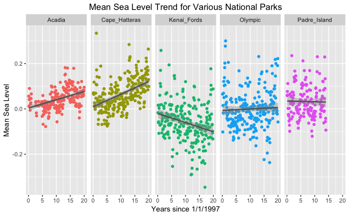

```r
ggplot(prob1Melt, aes(years, MSL, color = National_Park)) +
  geom_point(na.rm = TRUE) +
  facet_grid(. ~ National_Park) +
  labs(title = "Mean Sea Level Trend for Various National Parks", x = "Years since 1/1/1997", y = "Mean Sea Level") +
  theme(plot.title = element_text(hjust = 0.5), legend.position = "none") +
  geom_smooth(method = 'lm', formula = y ~ x, na.rm = TRUE, color = "gray40")
```

For further reference, there is a full list of colors for ggplot2 on this [site](http://sape.inf.usi.ch/quick-reference/ggplot2/colour).

Notice that the sea level change at Padre Island doesn’t match the increase given in the excel sheet. To understand this, we can look at the larger data set.

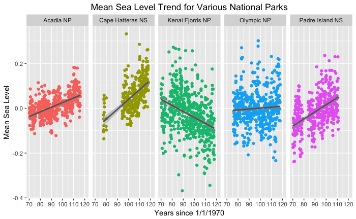

```r
#Keep just the data since 1970
mslFull <- acadia[-(1:840),]
mslFull$National_Park <- as.character(npsMSL2[2,2])
for (i in 3:ncol(npsMSL2) ) {
  dfTemp <- read.csv(paste("https://tidesandcurrents.noaa.gov/sltrends/downloadMeanSeaLevelTrendsCSV.htm?stnid=",as.character(as.integer(npsMSL2[1, i])),sep=""))
  dfTemp$National_Park <- as.character(npsMSL2[2,i])
  dfTemp$years <- as.numeric(row.names(dfTemp))/12
  #Keep just the data since 1970
  dfTemp <- dfTemp[-(1:840),]
  mslFull <- rbind(mslFull, dfTemp)
}
ggplot(mslFull, aes(years, Monthly_MSL, color = National_Park)) +
  geom_point(na.rm = TRUE) +
  facet_grid(. ~ National_Park) +
  labs(title = "Mean Sea Level Trend for Various National Parks", x = "Years since 1/1/1970", y = "Mean Sea Level") +
  theme(plot.title = element_text(hjust = 0.5), legend.position = "none") +
  geom_smooth(method = 'lm', formula = y ~ x, na.rm = TRUE, color = "gray40")
```

```r
dfLm <- as.data.frame(unique(mslFull$National_Park))
colnames(dfLm) <- c("National_Park")
for(i in 1:nrow(dfLm)){
  dfTemp <- filter(mslFull, National_Park == dfLm$National_Park[i])
  fit3 <- lm(Monthly_MSL ~ years,dfTemp)
  dfLm$Upper_95[i] <- round((1000*confint(fit3, 'years', level=0.95))[2],2)
  dfLm$MSL_Trend_Value[i] <- round(1000*fit3$coefficients[2],2)
  dfLm$Lower_95[i] <- round((1000*confint(fit3, 'years', level=0.95))[1],2)
}
dfLm
```

| National_Park | Upper_95 | MSL_Trend_Value | Lower_95 |
| --- | --- | --- | --- |
| Acadia NP | 2.34 | 2.07 | 1.79 |
| Cape Hatteras NS | 5.14 | 4.38 | 3.63 |
| Kenai Fjords NP | -2.11 | -2.68 | -3.26 |
| Olympic NP | 0.98 | 0.41 | -0.16 |
| Padre Island NS | 3.73 | 3.17 | 2.61 |

### Step 2 - Creating the Model - Adlai E Stevenson HS

The [winning solution](https://m3challenge.siam.org/sites/default/files/uploads/8597%20Adlai%20E%20Stevenson%20High%20School.pdf) was from Adlai E Stevenson HS. We examine their solution.

To do so, we first realize that the information given to us on sheet 2 of the Excel sheet will be our guiding data.

```r
npsMSL2
```

| Station location | Bar Harbor, ME | Oregon Inlet Marina, NC | Seward, AK | Port Angeles, WA | Padre Island, TX |
| --- | --- | --- | --- | --- | --- |
| Station ID | 8413320.0 | 8652587.0 | 9455090.0 | 9444090.0 | 8779750.0 |
| NPS park unit | Acadia NP | Cape Hatteras NS | Kenai Fjords NP | Olympic NP | Padre Island NS |
| Upper 95% mm/yr | 2.4 | 5.07 | -1.93 | 1.1 | 4.23 |
| MSL Trend Value mm/yr | 2.178 | 3.84 | -2.62 | 0.14 | 3.48 |
| Lower 95% mm/yr | 1.96 | 2.61 | -3.31 | -0.82 | 2.73 |

```r
qnorm(.025, mean = 0, sd = 1)
```

```
[1] -1.959964
```

```r
qnorm(.975, mean = 0, sd = 1)
```

```
[1] 1.959964
```

Thus, they need to figure out the corresponding situation in their case using these values. For Acadia NP, this looks like

```r
mu <- 2.178
sd <- (2.4 - mu)/qnorm(.975, mean = 0, sd = 1)
sd
```

```
[1] 0.1132674
```

Now, looking at the rise in sea levels over the next 10 years. We would expect them to rise 2.178 mm/year * 10 years = 21.78 mm. However, the sea level trend is probabilistic, so we need to take this into account. We do so by developing a new normal distribution with mean = 2.178 * 10 and standard deviation = 0.1132674 * 10^.5. (Why is this the case? See this [article](https://www.statlect.com/probability-distributions/normal-distribution-linear-combinations).)

We can see this in the following calculation. For a rise of 2.178 mm/year, we would expect ~42 years to reach the threshold of 91.44 mm. Looking at the probabilities after 42 years.

```r
t <- 42
"Low Risk"
```

```
[1] "Low Risk"
```

```r
print(pnorm(91.44, mean = mu*t, sd = sd*t^.5))
```

```
[1] 0.4804427
```

```r
"Med Risk"
```

```
[1] "Med Risk"
```

```r
print(pnorm(300.8, mean = mu*t, sd = sd*t^.5) - pnorm(91.44, mean = mu*t, sd = sd*t^.5))
```

```
[1] 0.5195573
```

```r
"High Risk"
```

```
[1] "High Risk"
```

```r
print(1 - pnorm(300.8, mean = mu*t, sd = sd*t^.5))
```

```
[1] 0
```

So, now to calculate the probabilites of risk for the assigned years (10, 20, 50, and 100).

```r
dfRisk <- as.data.frame(matrix(NA, nrow = 20, ncol = 5))
colnames(dfRisk) <- c("Station", "Years", "Low", "Med", "High")
count <- 1
str(dfRisk)
```

```
'data.frame':   20 obs. of  5 variables:
 $ Station: logi  NA NA NA NA NA NA ...
 $ Years  : logi  NA NA NA NA NA NA ...
 $ Low    : logi  NA NA NA NA NA NA ...
 $ Med    : logi  NA NA NA NA NA NA ...
 $ High   : logi  NA NA NA NA NA NA ...
```

```r
for(i in 2:ncol(npsMSL2)){
  station <- as.character(npsMSL2[2,i])
  mu <- as.numeric(npsMSL2[4,i])
  sd <- (as.numeric(npsMSL2[3,i]) - mu)/qnorm(0.975)
  for(t in c(10,20,50,100)) {
    dfRisk$Years[count] <- t
    dfRisk$Station[count] <- station
    dfRisk$Low[count] <- round(pnorm(91.44, mean = mu*t, sd = sd*t^.5),3)
    dfRisk$Med[count] <- round(pnorm(300.8, mean = mu*t, sd = sd*t^.5) - pnorm(91.44, mean = mu*t, sd = sd*t^.5),3)
    dfRisk$High[count] <- round(1 - pnorm(300.8, mean = mu*t, sd = sd*t^.5), 3)
    count <- count + 1
  }
}
dfRisk
```

| Station | Years | Low | Med | High |
| --- | --- | --- | --- | --- |
| Acadia NP | 10 | 1 | 0 | 0 |
| Acadia NP | 20 | 1 | 0 | 0 |
| Acadia NP | 50 | 0 | 1 | 0 |
| Acadia NP | 100 | 0 | 1 | 0 |
| Cape Hatteras NS | 10 | 1 | 0 | 0 |
| Cape Hatteras NS | 20 | 1 | 0 | 0 |
| Cape Hatteras NS | 50 | 0 | 1 | 0 |
| Cape Hatteras NS | 100 | 0 | 0 | 1 |
| Kenai Fjords NP | 10 | 1 | 0 | 0 |
| Kenai Fjords NP | 20 | 1 | 0 | 0 |

[output cut: 10 more lines]

The team then picked the risk rating with the highest probability as the rating for that year.